# NYPD Shooting Incident Analysis

Anastasiia Stukova

2025-01-21

## Executive Summary

This report presents an in-depth analysis of shooting incidents in New York City based on publicly available NYPD data. We aim to understand patterns, identify high-risk areas and times, and provide data-driven recommendations for improving public safety.

### Methodology

Our analysis combines statistical analysis with data visualization to examine: - Time-based patterns (annual trends, daily patterns) - Geographic distribution - Demographic profiles - Fatality rates and risk factors

## Impact and Implications

These findings have significant implications for: - Law enforcement resource allocation - Community safety programs - Public policy development - Emergency response planning

## Data Preparation

```r
csv_url <- "https://data.cityofnewyork.us/api/views/833y-fsy8/rows.csv?accessType=DOWNLOAD"

shooting_data <- read_csv(csv_url) %>%
  mutate(
    OCCUR_DATE = mdy(OCCUR_DATE),
    OCCUR_TIME = hms(OCCUR_TIME),
    year = year(OCCUR_DATE),
    month = month(OCCUR_DATE),
    hour = hour(OCCUR_TIME)
  )
# Summary of the dataset
glimpse(shooting_data)
```

```
## Rows: 28,562
## Columns: 24
## $ INCIDENT_KEY            <dbl> 231974218, 177934247, 255028563, 25384540, 726…
## $ OCCUR_DATE              <date> 2021-08-09, 2018-04-07, 2022-12-02, 2006-11-1…
## $ OCCUR_TIME              <Period> 1H 6M 0S, 19H 48M 0S, 22H 57M 0S, 1H 50M 0S…
## $ BORO                    <chr> "BRONX", "BROOKLYN", "BRONX", "BROOKLYN", "BRO…
## $ LOC_OF_OCCUR_DESC       <chr> NA, NA, "OUTSIDE", NA, NA, NA, NA, NA, NA, NA,…
## $ PRECINCT                <dbl> 40, 79, 47, 66, 46, 42, 71, 69, 75, 69, 40, 42…
## $ JURISDICTION_CODE       <dbl> 0, 0, 0, 0, 0, 2, 0, 2, 0, 0, 0, 2, 0, 0, 2, 0…
## $ LOC_CLASSFCTN_DESC      <chr> NA, NA, "STREET", NA, NA, NA, NA, NA, NA, NA, …
## $ LOCATION_DESC           <chr> NA, NA, "GROCERY/BODEGA", "PVT HOUSE", "MULTI …
## $ STATISTICAL_MURDER_FLAG <lgl> FALSE, TRUE, FALSE, TRUE, TRUE, FALSE, TRUE, F…
## $ PERP_AGE_GROUP          <chr> NA, "25-44", "(null)", "UNKNOWN", "25-44", "18…
## $ PERP_SEX                <chr> NA, "M", "(null)", "U", "M", "M", NA, NA, "M",…
## $ PERP_RACE               <chr> NA, "WHITE HISPANIC", "(null)", "UNKNOWN", "BL…
## $ VIC_AGE_GROUP           <chr> "18-24", "25-44", "25-44", "18-24", "<18", "18…
## $ VIC_SEX                 <chr> "M", "M", "M", "M", "F", "M", "M", "M", "M", "…
## $ VIC_RACE                <chr> "BLACK", "BLACK", "BLACK", "BLACK", "BLACK", "…
## $ X_COORD_CD              <dbl> 1006343.0, 1000082.9, 1020691.0, 985107.3, 100…
## $ Y_COORD_CD              <dbl> 234270.0, 189064.7, 257125.0, 173349.8, 247502…
## $ Latitude                <dbl> 40.80967, 40.68561, 40.87235, 40.64249, 40.845…
## $ Longitude               <dbl> -73.92019, -73.94291, -73.86823, -73.99691, -7…
## $ Lon_Lat                 <chr> "POINT (-73.92019278899994 40.80967347200004)"…
## $ year                    <dbl> 2021, 2018, 2022, 2006, 2010, 2012, 2011, 2012…
## $ month                   <dbl> 8, 4, 12, 11, 5, 7, 7, 7, 4, 5, 10, 1, 5, 6, 9…
## $ hour                    <dbl> 1, 19, 22, 1, 1, 21, 22, 23, 15, 15, 0, 2, 22,…
```

## Trends

Annual Trends

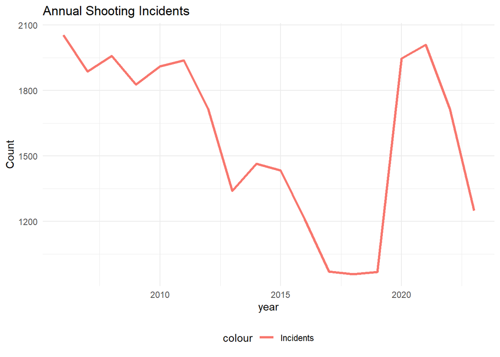

```r
annual_trend <- shooting_data %>%
  group_by(year) %>%
  summarise(
    incidents = n(),
    fatalities = sum(STATISTICAL_MURDER_FLAG == "true", na.rm = TRUE)
  )

ggplot(annual_trend, aes(x = year)) +
  geom_line(aes(y = incidents, color = "Incidents"), size = 1.2) +
  theme_minimal() +
  labs(title = "Annual Shooting Incidents",
       y = "Count") +
  theme(legend.position = "bottom")
```

Hourly Distribution

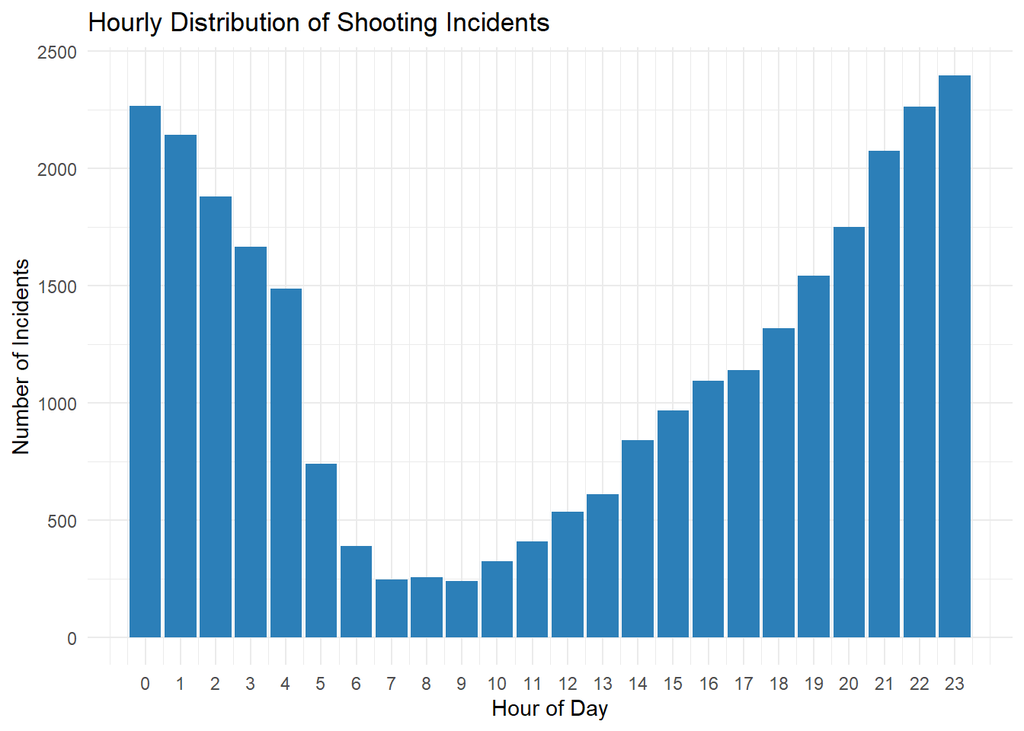

```r
hourly_dist <- shooting_data %>%
  group_by(hour) %>%
  summarise(incidents = n())

ggplot(hourly_dist, aes(x = hour, y = incidents)) +
  geom_bar(stat = "identity", fill = "#2c7fb8") +
  theme_minimal() +
  labs(
    title = "Hourly Distribution of Shooting Incidents",
    x = "Hour of Day",
    y = "Number of Incidents"
  ) +
  scale_x_continuous(breaks = 0:23)
```

Borough Analysis

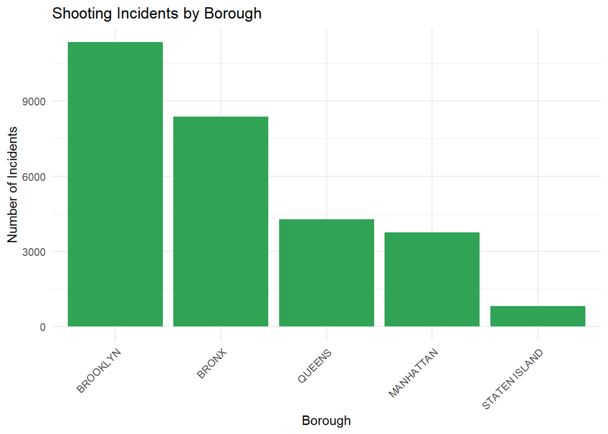

```r
borough_analysis <- shooting_data %>%
  group_by(BORO) %>%
  summarise(
    total_incidents = n(),
    fatal_incidents = sum(STATISTICAL_MURDER_FLAG == "true", na.rm = TRUE),
    fatality_rate = round((fatal_incidents / total_incidents) * 100, 2)
  )

ggplot(borough_analysis, aes(x = reorder(BORO, -total_incidents), y = total_incidents)) +
  geom_bar(stat = "identity", fill = "#31a354") +
  theme_minimal() +
  labs(
    title = "Shooting Incidents by Borough",
    x = "Borough",
    y = "Number of Incidents"
  ) +
  theme(axis.text.x = element_text(angle = 45, hjust = 1))
```

Key Statistics

```r
# Creating a table with key statistics
stats_summary <- data.frame(
  Metric = c(
    "Total Incidents",  # Total number of incidents
    "Total Fatalities", # Total number of fatalities
    "Most Affected Borough", # Borough with the highest number of incidents
    "Peak Hour" # Hour with the most incidents
  ),
  Value = c(
    nrow(shooting_data), # Calculates the total number of rows (incidents) in the dataset
    sum(as.logical(shooting_data$STATISTICAL_MURDER_FLAG), na.rm = TRUE), # Counts the total number of fatalities
    borough_analysis$BORO[which.max(borough_analysis$total_incidents)], # Finds the borough with the maximum incidents
    hourly_dist$hour[which.max(hourly_dist$incidents)] # Identifies the hour with the highest number of incidents
  )
)

# Displaying the key statistics table
kable(stats_summary, caption = "Key Statistics") %>%
  kable_styling(
    bootstrap_options = c("striped", "hover", "condensed"), # Adds styling options: striped rows, hover effect, compact layout
    full_width = FALSE # Ensures the table is not stretched to full width
  ) %>%
  row_spec(0, bold = TRUE, color = "white", background = "darkblue") %>% # Styles the header row: bold text, white font, dark blue background
  column_spec(1, bold = TRUE) %>% # Highlights the first column with bold text
  column_spec(2, color = "darkgreen") # Changes the color of the values in the second column to dark green
```

Key Statistics

| Metric | Value |
| --- | --- |
| Total Incidents | 28562 |
| Total Fatalities | 5526 |
| Most Affected Borough | BROOKLYN |
| Peak Hour | 23 |

Demographic Analysis

```r
demographic_profile <- shooting_data %>%
  group_by(VIC_AGE_GROUP, VIC_SEX) %>%
  summarise(
    incidents = n(),
    fatalities = sum(as.logical(STATISTICAL_MURDER_FLAG), na.rm = TRUE)
  ) %>%
  arrange(desc(incidents)) %>%
  mutate(fatality_rate = round((fatalities / incidents) * 100, 2)) #
kable(head(demographic_profile, 10), caption = "Top 10 Demographic Groups by Incidents") %>%
  kable_styling(bootstrap_options = c("striped", "hover", "condensed"), full_width = FALSE) %>%
  add_header_above(c(" " = 2, "Metrics" = 3))
```

Top 10 Demographic Groups by Incidents

| VIC_AGE_GROUP | VIC_SEX | Metrics incidents | Metrics fatalities | Metrics fatality_rate |
| --- | --- | --- | --- | --- |
| 25-44 | M | 11898 | 2587 | 21.74 |
| 18-24 | M | 9554 | 1595 | 16.69 |
| <18 | M | 2527 | 329 | 13.02 |
| 45-64 | M | 1615 | 394 | 24.40 |
| 25-44 | F | 1073 | 251 | 23.39 |
| 18-24 | F | 826 | 134 | 16.22 |
| <18 | F | 427 | 56 | 13.11 |
| 45-64 | F | 366 | 98 | 26.78 |
| 65+ | M | 142 | 49 | 34.51 |
| 65+ | F | 63 | 17 | 26.98 |

## Conclusions and Recommendations

**Key Findings**

### **Demographic Trends**

- **Male victims aged 18-44** are the most affected demographic group.
- **Young males under 24** are particularly vulnerable to incidents.

**Recommendations**

### **Targeted Law Enforcement**

- **Deploy additional patrols** during peak hours (**10 PM - 2 AM**).
- Focus resources in **high-risk boroughs**, such as **Brooklyn**.

### **Community Engagement**

- **Develop prevention programs** targeting **young males under 24**.
- Collaborate with **community leaders** to promote safety initiatives.

### **Policy Adjustments**

- **Analyze seasonal trends** to optimize resource allocation during high-risk periods.
- **Increase investment in public safety infrastructure** in vulnerable boroughs.